# DEM 7223 - Event History Analysis - Discrete Time Hazard Model 2

[Corey S. Sparks, PhD](https://coreysparks.github.io)

[The University of Texas at San Antonio](https://hcap.utsa.edu/demography)

October 19, 2020

# Notes

As we saw yesterday, when we fit the discrete time hazards model to the person-period data, we fit the model:

$$logit(h(t))=\alpha_j+x'β$$

Where the $\alpha_j$’s represent the logit-hazard for the distinct risk periods, and the $\beta$’s represent the effects of covariates on the hazard.

This formulation is called the “general” form because it allows the shape of the hazard function to vary at each time point, as defined by the $\alpha_j$’s!  
This allows great flexibility in modeling the changing nature of risk

This model specification by definition sets no constraints on the shape of the baseline function because we estimate the hazard at every time point This specification is:

- Easily interpretable in multiple scales
- Informative about the shape of the hazard function
- Consistent with estimates from life tables
  - If we include no predictors, we basically estimate the life table q(x)

### Alternative time specifications

We can specify alternative ways of modeling the hazard function

Instead of having one $\alpha_j$ for each time point, we may be able to capture the shape of the hazard with fewer parameters.

Because the general model is not parsimonious, the estimates of the baseline hazard can fluctuate dramatically from time to time owing solely to sampling variation

Also, if there are not many failures at particular times, we can have low certainty about the parameter estimate

Although time in the general model is treated discretely, we can specify continuous time models as well by specifying time as a continuous, rather than a categorical predictor in our model

This is done by assuming time is either:

- Constant – hazard is constant at all time, time is not in the model at all
- Linear – hazard increases/decreases with time
- Quadratic – hazard is a nonlinear curve over time with 1 inflection point
- Cubic – hazard is nonlinear over time with 2 inflection points
- Higher order – hazard is nonlinear over time with >2 inflection points
- Spline basis – nonlinear but not specifically using polynomials

Each of these models specifies a more parsimonious version of the general form, with fewer parameters, *if the number of time points is large*

But, they will never fit the data as well as the general model

### Comparing model fit for different time specifications

To compare discrete time models we use standard model comparison methods

- Model Deviance = (-2*log likelihood)
- Model AIC = (-2 log likelihood + 2*(p+1))

For example, if we fit the constant hazard, the linear hazard, a cubic hazard and a quartic hazard, we compare the performance of each model to the performance of the general model (with 1 parameter for each time point)

We get:

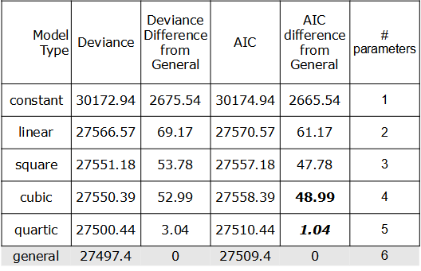

AIC Table

We see the General model is the best fitting, but the quartic model is the next best.

## Constructing Survival Curves for the discrete time model

We have seen how to plot the hazard function for the discrete time model, but we can also plot the survival function estimates as well.

If we use the product-limit estimator, then we can estimate survival to time t as:

$$S(t) = S_{t-1} * (1-h_t)$$

# Examples

This example will illustrate how to fit the discrete time hazard model to person-period data. Specifically, this example illustrates various parameterizartions of time in the discrete time model. In this example, I will use the event of a couple having a second birth. The data for this example come from the model.data [Demographic and Health Survey for 2012](http://www.dhsprogram.com/data/model-datasets.cfm) children’s recode file. This file contains information for all births in the last 5 years prior to the survey.

The second example will use data from the [IPUMS NHIS](https://nhis.ipums.org/nhis/) and examine alternative methods for coding time between survey and mortality follow up.

# Continuous duration outcome - DHS data

### load the data

```r
library(haven)
model.dat<-read_dta("https://github.com/coreysparks/data/blob/master/ZZIR62FL.DTA?raw=true")
model.dat<-zap_labels(model.dat)
```

## Event - Second birth occurrence

In the DHS individual recode file, information on every live birth is collected using a retrospective birth history survey mechanism.

Since our outcome is time between first and second birth, we must select as our risk set, only women who have had a first birth.

The `bidx` variable indexes the birth history and if `bidx_01` is not missing, then the woman should be at risk of having a second birth (i.e. she has had a first birth, i.e. `bidx_01==1`).

I also select only non-twin births (`b0 == 0`).

The DHS provides the dates of when each child was born in Century Month Codes.

To get the interval for women who *actually had* a second birth, that is the difference between the CMC for the first birth `b3_01` and the second birth `b3_02`, but for women who had not had a second birth by the time of the interview, the censored time between births is the difference between `b3_01` and `v008`, the date of the interview.

```r
#We form a subset of variables
sub<-subset(model.dat, model.dat$bidx_01==1&model.dat$b0_01==0)

#Here I keep only a few of the variables for the dates, and some characteristics of the women, and details of the survey
sub2<-data.frame(CASEID=sub$caseid,
                 int.cmc=sub$v008,
                 fbir.cmc=sub$b3_01,
                 sbir.cmc=sub$b3_02,
                 marr.cmc=sub$v509,
                 rural=sub$v025,
                 educ=sub$v106,
                 age=sub$v012,
                 partneredu=sub$v701,
                 partnerage=sub$v730,
                 weight=sub$v005/1000000,
                 psu=sub$v021, strata=sub$v022)

sub2$agefb = (sub2$age - (sub2$int.cmc - sub2$fbir.cmc)/12)

#censoring indicator for death by age 5, in months (<=60 months)
sub2$secbi<-ifelse(is.na(sub2$sbir.cmc)==T, ((sub2$int.cmc))-((sub2$fbir.cmc)), (sub2$fbir.cmc-sub2$sbir.cmc))
sub2$b2event<-ifelse(is.na(sub2$sbir.cmc)==T,0,1)
table(sub2$b2event)
```

```
##
##    0    1
## 1237 4789
```

```r
sub2$educ.high<-ifelse(sub2$educ %in% c(2,3), 1, 0)
sub2$age2<-(sub2$agefb)^2
sub2$partnerhiedu<-ifelse(sub2$partneredu<3,0,ifelse(sub2$partneredu%in%c(8,9),NA,1 ))
```

### Create the person-period file

The distinction between the way we have been doing things and the discrete time model, is that we treat time discretely, versus continuously. This means that we transform the data from the case-duration data format to the person-period format. For this example, a natural choice would be year, since we have intervals of equal length (12 months each).

R provides a useful function called `survSplit()` in the `survival` library that will split a continuous duration into discrete periods.

```r
library(survival)
#make person period file
pp<-survSplit(Surv(secbi, b2event)~. , data = sub2[sub2$secbi>0,],
              cut=c(0,12, 24, 36, 48, 60, 72),  episode="year_birth")

pp$year <- pp$year_birth-1
pp<-pp[order(pp$CASEID, pp$year_birth),]
head(pp[, c("CASEID", "secbi", "b2event", "year", "educ.high", "agefb")], n=20)
```

|  | CASEID | secbi | b2event | year | educ.high | agefb |
| --- | --- | --- | --- | --- | --- | --- |
| 1 | 1 1 2 | 12 | 0 | 1 | 0 | 29.58333 |
| 2 | 1 1 2 | 24 | 0 | 2 | 0 | 29.58333 |
| 3 | 1 1 2 | 32 | 1 | 3 | 0 | 29.58333 |
| 4 | 1 3 2 | 12 | 0 | 1 | 1 | 19.50000 |
| 5 | 1 3 2 | 24 | 0 | 2 | 1 | 19.50000 |
| 6 | 1 3 2 | 30 | 0 | 3 | 1 | 19.50000 |
| 7 | 1 4 2 | 12 | 0 | 1 | 0 | 31.66667 |
| 8 | 1 4 2 | 24 | 0 | 2 | 0 | 31.66667 |
| 9 | 1 4 2 | 32 | 1 | 3 | 0 | 31.66667 |
| 10 | 1 4 3 | 12 | 0 | 1 | 0 | 24.16667 |

[output cut: 10 more lines]

### Discrete time model

So, the best thing about the discrete time model, is that it’s just logistic regression. Each risk period is treated as a single Bernoulli trial, and the birth can either occur (y=1) or not (y=0) in the period. This is how we get the hazard of the event, as the estimated probability of failure in each discrete time period. So, any method you would like to use to model this probability would probably work (logit, probit models), but I will show two standard approaches.

```r
#generate survey design
library(survey)
options(survey.lonely.psu = "adjust")
des<-svydesign(ids=~psu, strata = ~strata , weights=~weight, data=pp)

#Fit the basic logistic model with ONLY time in the model
#I do -1 so that no intercept is fit in the model, and we get a hazard estimate for each time period
fit.0<-svyglm(b2event~as.factor(year)-1,design=des , family="binomial")
summary(fit.0)
```

```
##
## Call:
## svyglm(formula = b2event ~ as.factor(year) - 1, design = des,
##     family = "binomial")
##
## Survey design:
## svydesign(ids = ~psu, strata = ~strata, weights = ~weight, data = pp)
##
## Coefficients:
##                  Estimate Std. Error t value Pr(>|t|)
## as.factor(year)1 -4.62968    0.17640 -26.245  < 2e-16 ***
## as.factor(year)2 -1.80896    0.05286 -34.222  < 2e-16 ***
## as.factor(year)3 -0.76732    0.04603 -16.669  < 2e-16 ***
## as.factor(year)4 -0.70704    0.06203 -11.399  < 2e-16 ***
## as.factor(year)5 -0.92652    0.06158 -15.045  < 2e-16 ***
## as.factor(year)6 -0.92979    0.08186 -11.359  < 2e-16 ***
## as.factor(year)7  0.80355    0.10880   7.386  5.1e-12 ***
## ---
## Signif. codes:  0 '***' 0.001 '**' 0.01 '*' 0.05 '.' 0.1 ' ' 1
##
## (Dispersion parameter for binomial family taken to be 1.000044)
##
## Number of Fisher Scoring iterations: 7
```

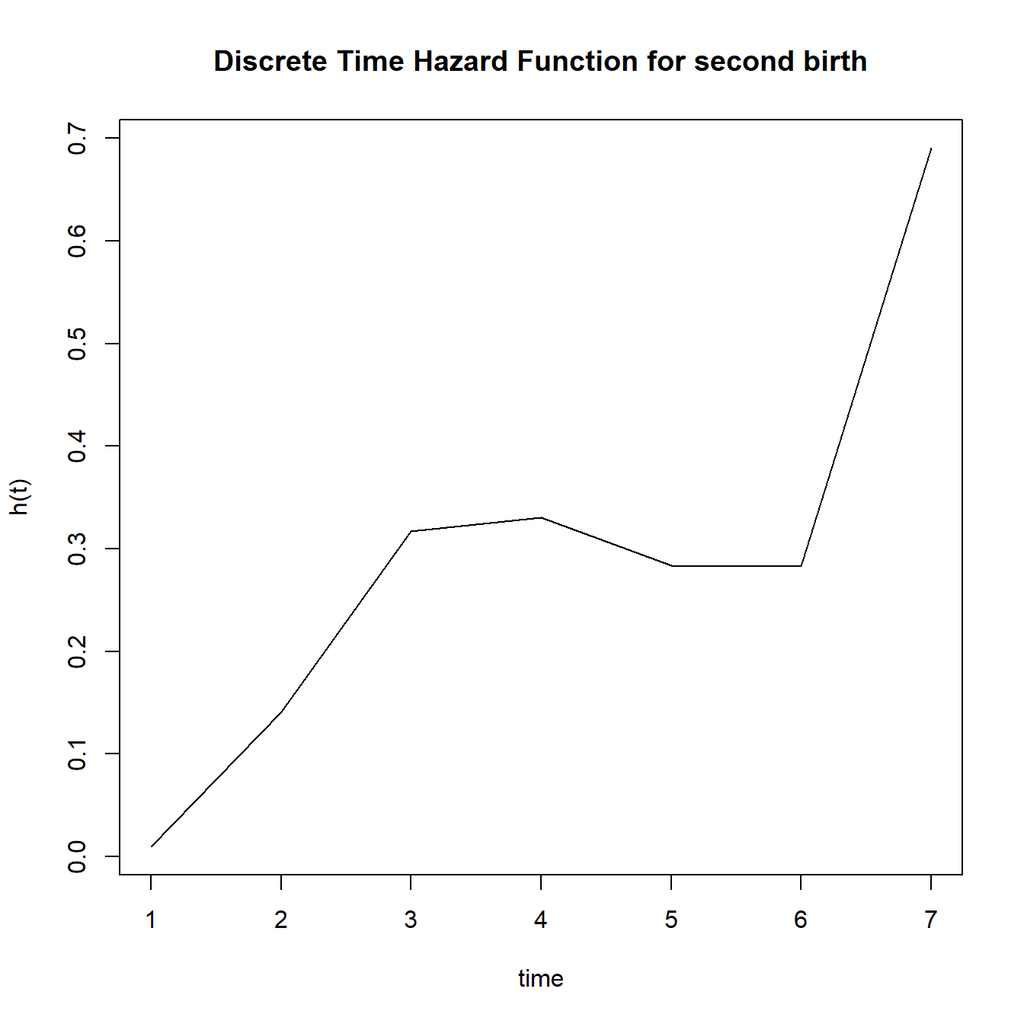

```r
#Plot the hazard function on the probability scale
haz<-1/(1+exp(-coef(fit.0)))
time<-seq(1,7,1)
plot(haz~time, type="l", ylab="h(t)")
title(main="Discrete Time Hazard Function for second birth")
```

### Plot the survival function estimate

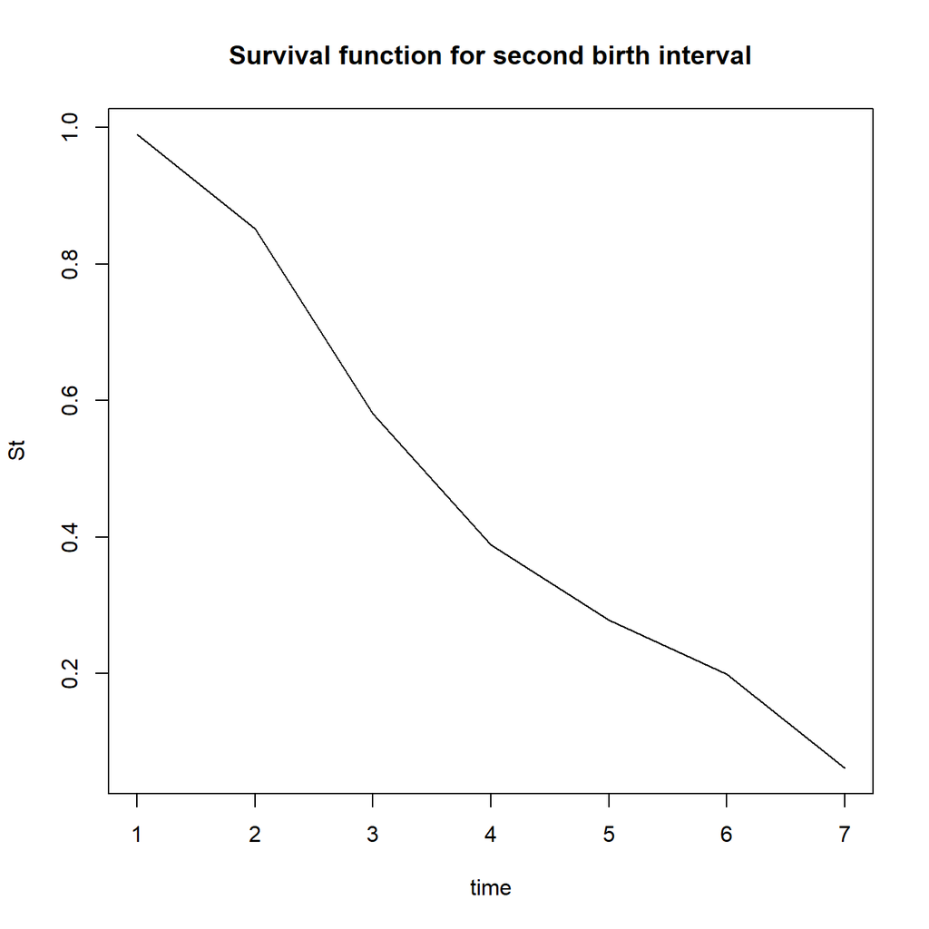

```r
St<-NA
time<-1:length(haz)
St[1]<-1-haz[1]
for(i in 2:length(haz)){
  St[i]<-St[i-1]* (1-haz[i])
}


plot(y=St,x=time, type="l", main="Survival function for second birth interval")
```

### Alternative time specifications

Here, we can specify how we want time in our model. The general model fits a hazard at every time point. If you have a lot of time points, and especially if you have low numbers of events at some time points, this can be computationally expensive.

We can, however, specify time as a linear or quadratic term, and the model will not fit separate hazards at all times, instead, the baseline hazard will be a linear or curvilinear function of time.

```r
#Linear term for time
fit.l<-svyglm(b2event~year,design=des , family="binomial")
summary(fit.l)
```

```
##
## Call:
## svyglm(formula = b2event ~ year, design = des, family = "binomial")
##
## Survey design:
## svydesign(ids = ~psu, strata = ~strata, weights = ~weight, data = pp)
##
## Coefficients:
##             Estimate Std. Error t value Pr(>|t|)
## (Intercept) -2.90143    0.04425  -65.56   <2e-16 ***
## year         0.48399    0.01231   39.32   <2e-16 ***
## ---
## Signif. codes:  0 '***' 0.001 '**' 0.01 '*' 0.05 '.' 0.1 ' ' 1
##
## (Dispersion parameter for binomial family taken to be 0.9228536)
##
## Number of Fisher Scoring iterations: 4
```

Which shows the hazard increases over time, which makes a lot of sense in the context of this outcome. Now we can consider quadratic terms for time and a natural spline function of time as well:

```r
fit.s<-svyglm(b2event~year+I(year^2),design=des , family="binomial")
summary(fit.s)
```

```
##
## Call:
## svyglm(formula = b2event ~ year + I(year^2), design = des, family = "binomial")
##
## Survey design:
## svydesign(ids = ~psu, strata = ~strata, weights = ~weight, data = pp)
##
## Coefficients:
##              Estimate Std. Error t value Pr(>|t|)
## (Intercept) -4.364954   0.099119  -44.04   <2e-16 ***
## year         1.421368   0.064178   22.15   <2e-16 ***
## I(year^2)   -0.121211   0.008288  -14.62   <2e-16 ***
## ---
## Signif. codes:  0 '***' 0.001 '**' 0.01 '*' 0.05 '.' 0.1 ' ' 1
##
## (Dispersion parameter for binomial family taken to be 0.8899194)
##
## Number of Fisher Scoring iterations: 5
```

```r
fit.c<-svyglm(b2event~year+I(year^2)+I(year^3 ),design=des , family="binomial")
summary(fit.c)
```

```
##
## Call:
## svyglm(formula = b2event ~ year + I(year^2) + I(year^3), design = des,
##     family = "binomial")
##
## Survey design:
## svydesign(ids = ~psu, strata = ~strata, weights = ~weight, data = pp)
##
## Coefficients:
##               Estimate Std. Error t value Pr(>|t|)
## (Intercept) -10.193252   0.355177  -28.70   <2e-16 ***
## year          7.053531   0.284805   24.77   <2e-16 ***
## I(year^2)    -1.688779   0.070271  -24.03   <2e-16 ***
## I(year^3)     0.129140   0.005371   24.05   <2e-16 ***
## ---
## Signif. codes:  0 '***' 0.001 '**' 0.01 '*' 0.05 '.' 0.1 ' ' 1
##
## (Dispersion parameter for binomial family taken to be 1.016774)
##
## Number of Fisher Scoring iterations: 6
```

```r
fit.q<-svyglm(b2event~year+I(year^2)+I(year^3 )+I(year^4),design=des , family="binomial")
summary(fit.q)
```

```
##
## Call:
## svyglm(formula = b2event ~ year + I(year^2) + I(year^3) + I(year^4),
##     design = des, family = "binomial")
##
## Survey design:
## svydesign(ids = ~psu, strata = ~strata, weights = ~weight, data = pp)
##
## Coefficients:
##              Estimate Std. Error t value Pr(>|t|)
## (Intercept) -9.283277   0.617622 -15.031  < 2e-16 ***
## year         5.864429   0.739788   7.927 2.01e-13 ***
## I(year^2)   -1.167265   0.316776  -3.685   0.0003 ***
## I(year^3)    0.036774   0.056085   0.656   0.5128
## I(year^4)    0.005659   0.003465   1.633   0.1041
## ---
## Signif. codes:  0 '***' 0.001 '**' 0.01 '*' 0.05 '.' 0.1 ' ' 1
##
## (Dispersion parameter for binomial family taken to be 0.9833714)
##
## Number of Fisher Scoring iterations: 7
```

```r
#Spline
library(splines)
fit.sp<-svyglm(b2event~ns(year, df = 2),design=des , family="binomial")
summary(fit.sp)
```

```
##
## Call:
## svyglm(formula = b2event ~ ns(year, df = 2), design = des, family = "binomial")
##
## Survey design:
## svydesign(ids = ~psu, strata = ~strata, weights = ~weight, data = pp)
##
## Coefficients:
##                   Estimate Std. Error t value Pr(>|t|)
## (Intercept)       -3.34925    0.06334  -52.88   <2e-16 ***
## ns(year, df = 2)1  5.11302    0.14699   34.79   <2e-16 ***
## ns(year, df = 2)2  1.87052    0.07779   24.05   <2e-16 ***
## ---
## Signif. codes:  0 '***' 0.001 '**' 0.01 '*' 0.05 '.' 0.1 ' ' 1
##
## (Dispersion parameter for binomial family taken to be 0.8878417)
##
## Number of Fisher Scoring iterations: 5
```

Now, let’s look at the hazards:

```r
dat<-expand.grid(year=seq(1,7,1))
dat$genmod<-predict(fit.0, newdata=data.frame(year=as.factor(1:7 )), type="response")
dat$lin<-predict(fit.l, newdata=dat, type="response")
dat$sq<-predict(fit.s, newdata=dat, type="response")
dat$cub<-predict(fit.c, newdata=dat, type="response")
dat$quart<-predict(fit.q, newdata=dat, type="response")
dat$spline<-predict(fit.sp, newdata=expand.grid(year=seq(1,7,1)), type="response")

dat
```

| year | genmod | lin | sq | cub | quart | spline |
| --- | --- | --- | --- | --- | --- | --- |
| 1 | 0.009663545 | 0.08185227 | 0.04458293 | 0.00901902 | 0.0105223 | 0.03391982 |
| 2 | 0.140764128 | 0.12636908 | 0.11846357 | 0.14085800 | 0.1371997 | 0.08454080 |
| 3 | 0.317059095 | 0.19008469 | 0.23294675 | 0.32193875 | 0.3221063 | 0.18017019 |
| 4 | 0.330252847 | 0.27578458 | 0.35004230 | 0.32418607 | 0.3319030 | 0.29978624 |
| 5 | 0.283631962 | 0.38190325 | 0.42840012 | 0.26844810 | 0.2671369 | 0.38977434 |
| 6 | 0.282966997 | 0.50062836 | 0.45008398 | 0.31566529 | 0.3012989 | 0.43823616 |
| 7 | 0.690733713 | 0.61928266 | 0.41224253 | 0.67403240 | 0.6840107 | 0.46295669 |

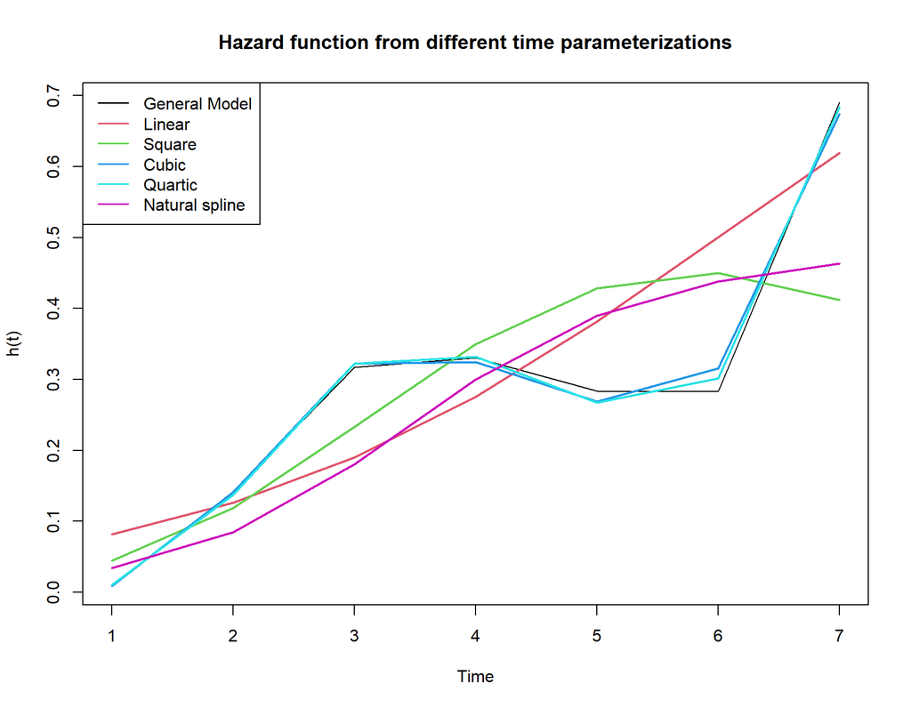

```r
plot(genmod~year, dat, type="l", ylab="h(t)", xlab="Time")
title(main="Hazard function from different time parameterizations")
lines(lin~year, dat, col=2, lwd=2)
lines(sq~year, dat, col=3, lwd=2)
lines(cub~year, dat, col=4, lwd=2)
lines(quart~year, dat, col=5, lwd=2)
lines(spline~year, dat, col=6, lwd=2)

legend("topleft", legend=c("General Model", "Linear","Square", "Cubic", "Quartic", "Natural spline"), col=1:6, lwd=1.5)
```

```r
#AIC table
aic<-round(c(
  fit.l$deviance+2*length(fit.l$coefficients),
  fit.s$deviance+2*length(fit.s$coefficients),
  fit.c$deviance+2*length(fit.c$coefficients),
  fit.q$deviance+2*length(fit.q$coefficients),
  fit.sp$deviance+2*length(fit.sp$coefficients),
  fit.0$deviance+2*length(fit.0$coefficients)),2)

#compare all aics to the one from the general model
dif.aic<-round(aic-aic[6],2)
data.frame(model =c( "linear","square", "cubic", "quartic","spline", "general"), aic=aic, aic_dif=dif.aic)
```

| model | aic | aic_dif |
| --- | --- | --- |
| linear | 20607.84 | 1432.79 |
| square | 20176.93 | 1001.88 |
| cubic | 19179.70 | 4.65 |
| quartic | 19177.30 | 2.25 |
| spline | 19969.57 | 794.52 |
| general | 19175.05 | 0.00 |

## IPUMS NHIS Mortality example

```r
library(survey)
library(survival)
library(car)
dat<-haven::read_dta("C:/Users/ozd504/OneDrive - University of Texas at San Antonio/classes/dem7223/dem7223_20//data/nhis_00012.dta")
names(dat)
```

```
##  [1] "year"         "serial"       "strata"       "psu"          "nhishid"
##  [6] "hhweight"     "region"       "pernum"       "nhispid"      "hhx"
## [11] "fmx"          "px"           "perweight"    "sampweight"   "fweight"
## [16] "supp2wt"      "intervwyr"    "astatflg"     "cstatflg"     "telephone"
## [21] "age"          "sex"          "marstat"      "marst"        "marstcohab"
## [26] "cohabmarst"   "cohabevmar"   "birthyr"      "relate"       "famsize"
## [31] "momed"        "racea"        "hispeth"      "yrsinus"      "hispyn"
## [36] "usborn"       "citizen"      "racenew"      "educrec2"     "empstat"
## [41] "pooryn"       "incfamr82on"  "gotnewelf"    "gotssiwhy"    "gotnonssdis"
## [46] "gotdiv"       "gotchsup"     "gotstamp"     "poverty"      "poverty2"
## [51] "ownership"    "lowrent"      "health"       "height"       "weight"
## [56] "bmicalc"      "bmi"          "bedayr"       "hstatyr"      "wldayr"
## [61] "usualpl"      "typplsick"    "routcare"     "delaycost"    "famdelaycono"
## [66] "famdelaycost" "famybarcar"   "famybarcarno" "placecar"     "delayappt"
## [71] "delayhrs"     "delayphone"   "delaytrans"   "delaywait"    "ybarcare"
## [76] "ybardental"   "ybarglass"    "ybarmeds"     "ybarmental"   "alc5upyr"
## [81] "smokev"       "smokagereg"   "mortelig"     "mortstat"     "mortdody"
## [86] "mortucodld"   "mortwt"       "mortcms"      "mortndi"      "mortssa"
## [91] "mortwtsa"
```

```r
sub<-subset(dat, dat$mortelig==1&is.na(dat$racenew)==F)
samps<-sample(1:length(sub$year), size = 100000, replace = F)
sub<-sub[samps,]
sub<-zap_labels(sub)
```

### alternative codings of failure time

In mortality analysis, but in any type of case-duration data, we can construct our event indicator to represent if an event occurs during a set risk period. In the NHIS mortality, we could code the death as a few different ways:

If you are interested in the *Age at death*, then you will measure your outcome as the age when they died

```r
sub$d.age<-ifelse(sub$mortstat==1,sub$mortdody-(sub$year-sub$age) ,
                  ifelse(sub$mortstat==2,2009-(sub$year-sub$age), NA))
```

If you are interested in the risk of death in a follow up period, then you could code it as: - Did the person die in the follow up period at all? No time specified - Did the person die in a 1, 5, or 10 year period? This specifies a fixed risk period

```r
sub$d.event<-ifelse(sub$mortstat==1,1,0) #did they die?

sub$timetodeath<-ifelse(sub$mortstat ==1, sub$mortdody-sub$year  , 2009 - sub$year ) #how long after the interview did they die?

sub$d1yr<-ifelse(sub$timetodeath<=1&sub$mortstat==1, 1,0) #did they die within 1 year of the interview
sub$d5yr<-ifelse(sub$timetodeath<=5&sub$mortstat==1, 1,0) #did they die within 5 years of the interview
```

Other variables

```r
library(car)
sub$married<-Recode(sub$marstat, recodes="00=NA; 10:13='married'; 20:40='sep'; 50='nm'; 99=NA" ,as.factor=T )
sub$male<-ifelse(sub$sex==1,1,0)
sub$mwt<-sub$mortwt/mean(sub$mortwt, na.rm=T)

sub$age5<-cut(sub$age,seq(15,85, 5))

sub$race<-Recode(sub$racenew, recodes ="10='wht'; 20 ='blk'; 30:61='other'; 97:99=NA", as.factor=T)
sub$college<-Recode(sub$educrec2, recodes="00=NA; 10:42='hs or less'; 50:53='some coll'; 54:60='coll'; else=NA", as.factor=T)
sub$black<-ifelse(sub$race=='blk',1,0)
sub$oth<-ifelse(sub$race=='other',1,0)
sub$hs<-ifelse(sub$college=='hs or less',1,0)
sub$col1<-ifelse(sub$college=='some coll',1,0)
sub$sep<-ifelse(sub$married=='sep',1,0)
sub$nm<-ifelse(sub$married=='nm',1,0)

sub$race<-Recode(sub$racenew, recodes ="10='wht'; 20 ='blk'; 30:61='other'; 97:99=NA", as.factor=T)
sub$hisp<-Recode(sub$hispyn, recodes="1=0; 2=1; else=NA")

sub$race_eth[sub$hisp == 0 & sub$race=="wht"]<-"NHWhite"
sub$race_eth[sub$hisp == 0 & sub$race=="blk"]<-"NHBlack"
sub$race_eth[sub$hisp == 0 & sub$race=="other"]<-"NHother"
sub$race_eth[sub$hisp == 1 ]<-"Hispanic"
sub$race_eth[is.na(sub$hisp) ==T | is.na(sub$race)==T]<-NA

library(forcats)

sub$race_eth<-fct_relevel(sub$race_eth, c("NHWhite", "NHBlack" , "Hispanic", "NHother"))
```

### Create person - period file

```r
subpp<-survSplit(Surv(d.age, d.event)~., data=sub,
cut=seq(18, 100, 5),  episode="mort_5_yr")
```

Analysis of death outcome

```r
des2<-svydesign(ids=~psu, strata=~strata, weights = ~perweight, data=subpp, nest=T)

# constant model
m0<-svyglm(d.event~ race_eth+college,
           design=des2, family=binomial (link="logit"))
#general model
m1<-svyglm(d.event~factor(mort_5_yr) + race_eth+college,
           design=des2, family=binomial (link="logit"))
#linear model
m2<-svyglm(d.event~mort_5_yr+race_eth+college, design=des2,
           family=binomial (link="logit"))
#quadratic model
m3<-svyglm(d.event~mort_5_yr+ I(mort_5_yr^2)+race_eth+college,
           design=des2, family=binomial (link="logit"))
#spline model
library(splines)
m4<-svyglm(d.event~bs(mort_5_yr)+race_eth+college, design=des2,
           family=binomial (link="logit"))
```

## Generate hazard plots

```r
newdat<-expand.grid(mort_5_yr = unique(subpp$mort_5_yr),
                    race_eth= unique(subpp$race_eth),
                    college = unique(subpp$college))

newdat<-newdat%>%
  dplyr::filter(complete.cases(.))

newdat$h0<-predict(m0, newdata=newdat, type="response")
newdat$h1<-predict(m1, newdata=newdat, type="response")
newdat$h2<-predict(m2, newdata=newdat, type="response")
newdat$h3<-predict(m3, newdata=newdat, type="response")
newdat$h4<-predict(m4, newdata=newdat, type="response")

head(newdat)
```

|  | mort_5_yr | race_eth | college | h0 | h1 | h2 | h3 | h4 |
| --- | --- | --- | --- | --- | --- | --- | --- | --- |
| 1 | 1 | Hispanic | hs or less | 0.01435752 | 1.197185e-05 | 0.0002276312 | 0.0009802939 | 0.0001459505 |
| 2 | 2 | Hispanic | hs or less | 0.01435752 | 4.796000e-04 | 0.0004064463 | 0.0012444077 | 0.0004340518 |
| 3 | 3 | Hispanic | hs or less | 0.01435752 | 1.714969e-03 | 0.0007256269 | 0.0016419420 | 0.0010670178 |
| 4 | 4 | Hispanic | hs or less | 0.01435752 | 2.687751e-03 | 0.0012951342 | 0.0022516834 | 0.0022338214 |
| 5 | 5 | Hispanic | hs or less | 0.01435752 | 3.348156e-03 | 0.0023105849 | 0.0032088701 | 0.0041032936 |
| 6 | 6 | Hispanic | hs or less | 0.01435752 | 5.789451e-03 | 0.0041189167 | 0.0047510342 | 0.0068139185 |

```r
library(data.table)
library(magrittr)
out<-melt(setDT(newdat), id = c("mort_5_yr", "race_eth", "college"),
          measure.vars = list(haz=c("h0", "h1","h2","h3", "h4")))
head(out, n=20)
```

| mort_5_yr | race_eth | college | variable | value |
| --- | --- | --- | --- | --- |
| 1 | Hispanic | hs or less | h0 | 0.01435752 |
| 2 | Hispanic | hs or less | h0 | 0.01435752 |
| 3 | Hispanic | hs or less | h0 | 0.01435752 |
| 4 | Hispanic | hs or less | h0 | 0.01435752 |
| 5 | Hispanic | hs or less | h0 | 0.01435752 |
| 6 | Hispanic | hs or less | h0 | 0.01435752 |
| 7 | Hispanic | hs or less | h0 | 0.01435752 |
| 8 | Hispanic | hs or less | h0 | 0.01435752 |
| 9 | Hispanic | hs or less | h0 | 0.01435752 |
| 10 | Hispanic | hs or less | h0 | 0.01435752 |

[output cut: 10 more lines]

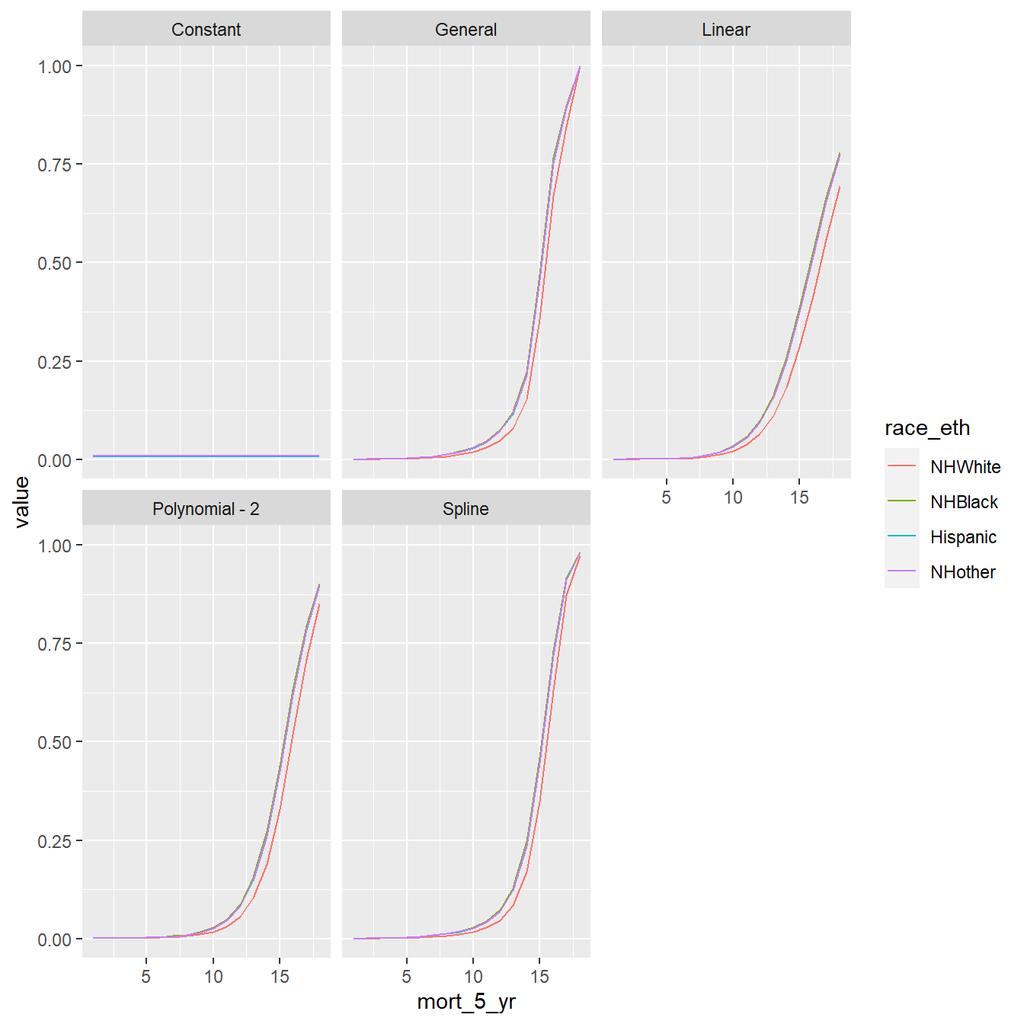

```r
library(ggplot2)

out%>%
  dplyr::filter(college == "coll")%>%
  dplyr::mutate(mod = dplyr::case_when(.$variable =="h0" ~ "Constant",
                          .$variable =="h1" ~ "General",
                          .$variable =="h2" ~ "Linear",
                          .$variable =="h3" ~ "Polynomial - 2",
                          .$variable =="h4" ~ "Spline"))%>%
  ggplot(aes(x = mort_5_yr, y=value))+geom_line(aes(group=race_eth, color=race_eth))+facet_wrap(~mod)#+ scale_y_continuous(trans = "log10")
```

### Model fits

Here we construct a table of the relative model fits for the five different time specifications

```r
AIC0<-AIC(m0)
AIC1<-AIC(m1)
AIC2<-AIC(m2)
AIC3<-AIC(m3)
AIC4<-AIC(m4)
AICS<-data.frame(AIC = c(AIC0["AIC"],AIC1["AIC"],AIC2["AIC"],AIC3["AIC"],AIC4["AIC"]),
                 mod = factor(c("const", "general", "linear", "poly 2", "spline")) )

AICS$mod<-forcats::fct_relevel(AICS$mod, c("general", "const" , "linear", "poly2", "spline"))
AICS$deltaAIC<-AICS$AIC-AICS$AIC[AICS$mod=="general"]

knitr::kable(AICS[, c("mod", "AIC", "deltaAIC")], caption = "Relative AIC for alternative time specifications")
```

Relative AIC for alternative time specifications

| mod | AIC | deltaAIC |
| --- | --- | --- |
| const | 121661.77 | 44126.2578 |
| general | 77535.51 | 0.0000 |
| linear | 78794.79 | 1259.2802 |
| poly 2 | 78207.55 | 672.0404 |
| spline | 77647.34 | 111.8309 |

We see that nothing touches the AIC for the general model in this case.